# Statistical Methods Final Project

Kyle Urban, James Joyner, Brennon

2026-04-26

Loading packages

```r
library(tidyverse)
```

```r
DATA <- read_csv("Teen_Mental_Health_Dataset.csv")
DATA
```

| age | gender | daily_social_media_hours | platform_usage | sleep_hours | screen_time_before_sleep | academic_performance | physical_activity | social_interaction_level | stress_level | anxiety_level | addiction_level | depression_label |
| --- | --- | --- | --- | --- | --- | --- | --- | --- | --- | --- | --- | --- |
| 14 | male | 7.9 | Instagram | 7.4 | 2.9 | 3.01 | 1.5 | low | 2 | 2 | 1 | 0 |
| 19 | female | 1.9 | TikTok | 8.0 | 2.9 | 3.22 | 0.8 | high | 8 | 1 | 10 | 0 |
| 17 | female | 1.3 | Instagram | 7.6 | 0.5 | 3.92 | 0.0 | high | 2 | 4 | 2 | 0 |
| 15 | male | 7.4 | TikTok | 6.9 | 1.6 | 3.48 | 0.8 | medium | 1 | 7 | 9 | 0 |
| 15 | female | 4.7 | Both | 4.9 | 3.0 | 2.37 | 1.4 | medium | 3 | 5 | 2 | 0 |
| 19 | female | 7.4 | Both | 4.4 | 2.4 | 2.63 | 0.6 | high | 3 | 5 | 7 | 0 |
| 18 | female | 2.5 | Instagram | 6.4 | 2.4 | 2.63 | 0.7 | low | 2 | 2 | 5 | 0 |
| 16 | male | 4.0 | Both | 4.2 | 0.5 | 2.40 | 1.3 | low | 6 | 10 | 5 | 0 |
| 19 | female | 3.3 | TikTok | 5.0 | 2.1 | 2.04 | 0.9 | high | 1 | 10 | 9 | 0 |
| 15 | male | 1.9 | TikTok | 4.9 | 1.5 | 3.77 | 1.1 | high | 1 | 1 | 4 | 0 |

[output cut: 1190 more lines]

Qualitative Variables: **gender**, **platform_usage**

### 0.1 Section 1.1 Qualitative Data

Qualitative Variable: **gender**

Success: **female**

Population size: N = 1200

#### 0.1.1 1. Select one qualitative variable and use one level of the qualitative variable as success and select a sample size of at least 50.

```r
# Frequency Table
DATA %>%
  count(gender, name = 'frequency') %>%
  mutate(rel_frequency = frequency/sum(frequency))
```

| gender | frequency | rel_frequency |
| --- | --- | --- |
| female | 585 | 0.4875 |
| male | 615 | 0.5125 |

Qualitative variable = gender

Success = female

Sample size: n = 50

Population proportion: p = 585/1200

```r
p <- 585/1200
p
```

```
## [1] 0.4875
```

#### 0.1.2 2. Show the number of successes is from binomial distribution.

Let X = number of females in a random sample of n = 50 teens.

**Checking Binomial Criteria:**

1. The experiment is performed a fixed number of times: n = 50 (fixed).
2. The trials are independent: n <= 0.05N → 50 <= 0.05 * 1200 = 60. Since 50 <= 60, the trials are independent.
3. For each trial, there are two mutually exclusive outcomes: female (success) or male (failure).
4. The probability of success is fixed for each trial: p = 585/1200 = 0.4875.

Since all four criteria are met, X ~ Bin(n = 50, p = 0.4875).

```r
# n = sample size
n <- 50

# Check independence: n <= 0.05N
n <= 0.05 * 1200
```

```
## [1] TRUE
```

```r
# PMF table for X ~ Bin(n = 50, p = 0.4875)
binom_pmf <- tibble(x_female = 0:50,
                    prob_female = dbinom(x = x_female, size = 50, prob = p))
binom_pmf
```

| x_female | prob_female |
| --- | --- |
| 0 | 3.052766e-15 |
| 1 | 1.451925e-13 |
| 2 | 3.383694e-12 |
| 3 | 5.149817e-11 |
| 4 | 5.755863e-10 |
| 5 | 5.037082e-09 |
| 6 | 3.593528e-08 |
| 7 | 2.148604e-07 |
| 8 | 1.098539e-06 |
| 9 | 4.876443e-06 |

[output cut: 41 more lines]

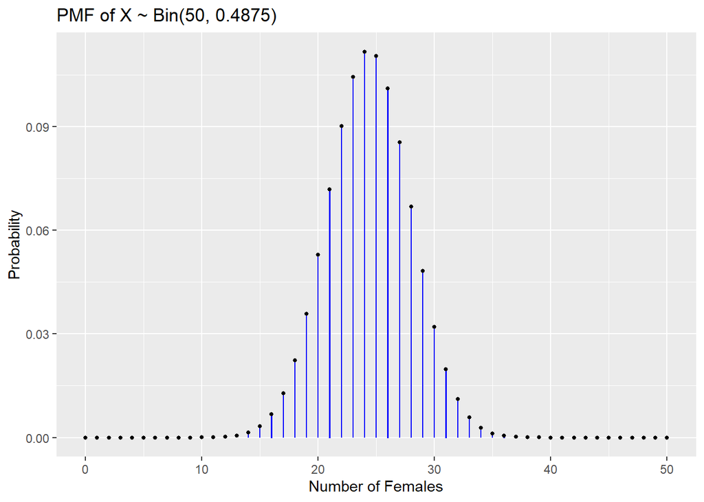

```r
# Graph of pmf
binom_pmf %>%
  ggplot(mapping = aes(x = x_female, y = prob_female)) +
  geom_col(width = 0.01, color = "blue") +
  geom_point(size = 1) +
  labs(x = "Number of Females",
       y = "Probability",
       title = "PMF of X ~ Bin(50, 0.4875)")
```

#### 0.1.3 3. Find the probability the random variable is more than its mean.

```r
# Mean: E(X) = np
mean_x <- n * p
mean_x
```

```
## [1] 24.375
```

```r
# Standard Deviation: SD(X) = sqrt(np(1-p))
sd_x <- sqrt(n * p * (1 - p))
sd_x
```

```
## [1] 3.534429
```

P(X > 24.375) = P(X >= 25) = 1 - P(X <= 24)

```r
# Method 1: Using pbinom
1 - pbinom(q = 24, size = 50, prob = p)
```

```
## [1] 0.4854444
```

```r
# Method 2: Summing individual probabilities
dbinom(x = 25:50, size = 50, prob = p) %>% sum()
```

```
## [1] 0.4854444
```

#### 0.1.4 4. Find the sampling distribution of the sample proportion of the qualitative variable with a sample size of at least 50.

$\hat{p}$ = sample proportion of females in a sample of n = 50

The sampling distribution of $\hat{p}$:

1. $\mu_{\hat{p}} = p = 0.4875$

```r
p
```

```
## [1] 0.4875
```

2. $\sigma_{\hat{p}} = \sqrt{\frac{p(1-p)}{n}}$

```r
sqrt(p * (1 - p) / n)
```

```
## [1] 0.07068858
```

3. Approximately normal if:
1. Simple random sample (assumed)
2. n <= 0.05N: 50 <= 0.05 * 1200 = 60
3. np(1-p) >= 10

```r
n * p * (1 - p)
```

```
## [1] 12.49219
```

np(1-p) = 12.49 >= 10

Since the requirements hold, $\hat{p}$ is approximately normal.

## 1 ——————————————————————————

### 1.1 Section 1.2 Quantitative Data

Quantitative Variable: **sleep_hours**

#### 1.1.1 1. Select one quantitative variable.

```r
DATA %>%
  summarise(mean_sleep = mean(sleep_hours, na.rm = T),
            sd_sleep = sd(sleep_hours, na.rm = T),
            median_sleep = median(sleep_hours, na.rm = T),
            IQR_sleep = IQR(sleep_hours, na.rm = T))
```

| mean_sleep | sd_sleep | median_sleep | IQR_sleep |
| --- | --- | --- | --- |
| 6.449417 | 1.442677 | 6.5 | 2.4 |

#### 1.1.2 2. Check if the quantitative variable is from normal distribution.

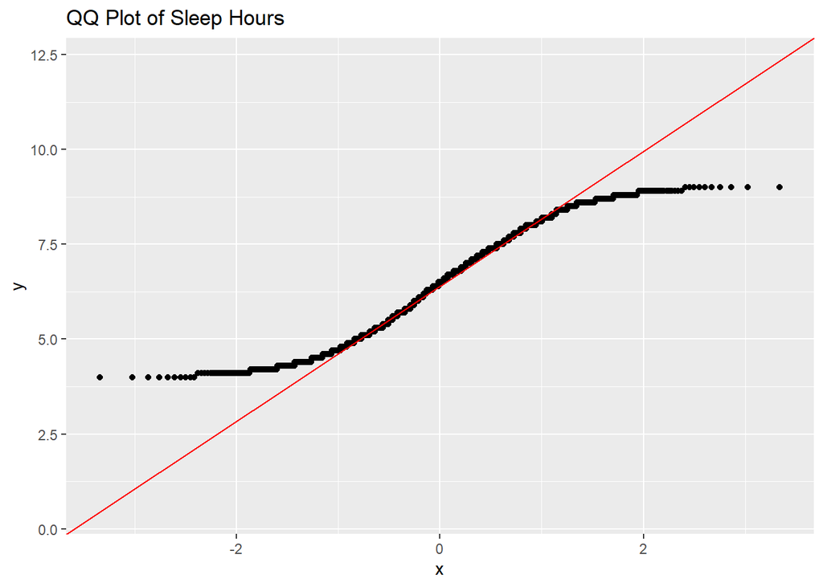

```r
# QQ Plot
DATA %>%
  ggplot(mapping = aes(sample = sleep_hours)) +
  stat_qq() +
  stat_qq_line(color = "red") +
  labs(title = "QQ Plot of Sleep Hours")
```

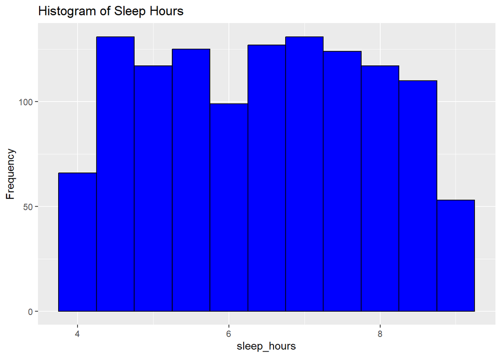

```r
# Histogram
DATA %>%
  ggplot(mapping = aes(x = sleep_hours)) +
  geom_histogram(fill = "blue", color = "black", binwidth = 0.5) +
  labs(y = "Frequency",
       title = "Histogram of Sleep Hours")
```

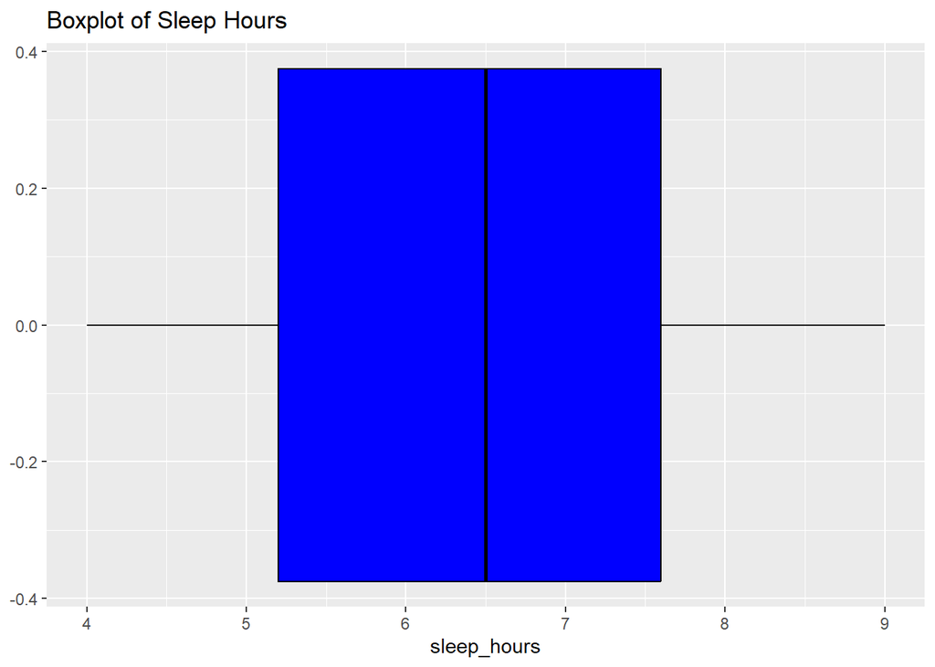

```r
# Boxplot
DATA %>%
  ggplot(mapping = aes(x = sleep_hours)) +
  geom_boxplot(fill = "blue", color = "black") +
  labs(title = "Boxplot of Sleep Hours")
```

#### 1.1.3 3. Find the sampling distribution of the sample mean of the quantitative variable with sample size of at least 50.

Population parameters (since this section assumes population data):

```r
# Population mean
mu_x <- mean(DATA$sleep_hours)
mu_x
```

```
## [1] 6.449417
```

```r
# Population standard deviation
sigma_x <- sd(DATA$sleep_hours)
sigma_x
```

```
## [1] 1.442677
```

Sample size: n = 50 (same as Section 1.1)

The sampling distribution of $\bar{X}$:

1. $\mu_{\bar{X}} = \mu_X$

```r
mu_x
```

```
## [1] 6.449417
```

2. $\sigma_{\bar{X}} = \sigma_X / \sqrt{n}$

```r
sigma_x / sqrt(50)
```

```
## [1] 0.2040254
```

Since the requirements hold, $\bar{X}$ is approximately normal.

#### 1.1.4 4. Find a probability of sample mean is greater than a number.

Find $P(\bar{X} > 6.5)$

```r
# P(X_bar > 6.5) = 1 - P(X_bar <= 6.5)
1 - pnorm(q = 6.5, mean = mu_x, sd = sigma_x / sqrt(50))
```

```
## [1] 0.4020956
```

## 2 ————————————————————-

## 3 Heading 2

## 4 ————————————————————-

### 4.1 2.1 Research Objectives

**Main Research Question:** Does screen time before sleep on social media platforms affect sleep hours, and does this relationship differ by gender?

#### 4.1.1 1. One sample confidence interval for the population proportion from the variable selected in Section 1.1.

Construct a 98% confidence interval for the proportion of teens who are female.

This establishes the demographic makeup of the population. Before comparing sleep patterns between genders, we need to understand the gender distribution and how confident we are in that estimate.

#### 4.1.2 2. One sample confidence interval for the population mean from the variable selected in Section 1.2.

Construct a 99% confidence interval for the mean sleep hours of teens.

This gives us a range for the true average sleep hours across all teens. Before investigating whether screen time is hurting sleep, we need a baseline estimate of how much sleep teens are actually getting.

#### 4.1.3 3. Formulate a research question to conduct a one-sample proportion hypothesis test based on the variable from Section 1.1.

$H_0: p = 0.50$

$H_A: p < 0.50$

This tests whether the gender split in the population is roughly even or skewed. If the dataset is heavily skewed toward one gender, that matters when we interpret the two-sample comparison of sleep hours later.

#### 4.1.4 4. Formulate a research question to conduct a one sample t test hypothesis test based on the variable in Section 1.2.

**Research Question:** Do teens get less than the recommended 8 hours of sleep?

$H_0: \mu = 8$

$H_A: \mu < 8$

The CDC recommends 8-10 hours of sleep for teens. Testing whether the mean sleep hours is significantly less than 8 directly addresses the core concern of our research question. If teens are not getting enough sleep, it motivates investigating screen time as a potential cause.

#### 4.1.5 5. Create a research question to do two sample mean (independent t test) hypothesis tests.

**Research Question:** Is there a difference in mean sleep hours between male and female teens?

$H_0: \mu_1 - \mu_2 = 0$ (no difference in mean sleep hours between males and females)

$H_A: \mu_1 - \mu_2 \neq 0$ (there is a difference in mean sleep hours between males and females)

This directly answers the second half of the main research question: “does this relationship differ by gender?” By comparing mean sleep hours between males and females, we can determine if one gender is sleeping significantly less than the other.

#### 4.1.6 6. Use two quantitative variables to show if there is a linear relationship between them.

**Research Question:** Is there a linear relationship between screen time before sleep and sleep hours?

$H_0: \beta_1 = 0$ $H_A: \beta_1 \neq 0$

### 4.2 2.2 Responsible Living

Responsible Living refers to maintaining you health whether that be physically or mentally. Sleep is a crucial part of maintaining good mental health. Sleep deprivation can lead to multiple health issues in adolescents. Sleep deprivation can lead to stress, depression, or even impede physical development of the brain. So it is important that we find the causes of sleep deprivation and encourage adolescents to get the recommended amount of sleep every night. Screentime is a common cause of sleep deprivation according to multiple studies into blue light and its effect on melatonin production. By understanding the relationship between screentime before sleep and sleep hours, we can make informed recommendations to teenagers about their screen time habits and how it may be affecting their sleep and overall mental health.

### 4.3 2.3 Data Overview:

1. The dataset used in this analysis is the Teenager Mental Health Dataset, a public dataset sourced from Kaggle, available at: https://www.kaggle.com/datasets/algozee/teenager-menthal-healy?resource=download
2. The dataset contains 1200 observations and multiple variables capturing various aspects of teenage mental health, lifestyle habits, and social media usage. For the purposes of this analysis.
3. We use these four variables in this analysis:

gender, platform_usage, sleep_hours, and screen_time_before_sleep

These four variables are the foundation of all research questions formulated in this analysis. gender and sleep_hours were selected in Section 1.1 and 1.2 respectively, while screen_time_before_sleep serves as the explanatory variable in the regression analysis. platform_usage provides additional categorical context explored during exploratory data analysis.